# Workflow Documentation

[output not shown]

```
## ℹ Loading idepGolem
```

```r
ROOT <- "/mnt/storage/"
```

#### Data Paths

This begins the process of loading the data. `get_idep_data()` returns a list of the data that will be used to process and examine the loaded expression data. To analyze a data set, just substitute the path to the expression data into `YOUR_DATA_PATH`. If your data comes with information about the samples, substitute the path for that file into `YOUR_EXPERIMENT_PATH`. These data paths are then stored in a data frame that will be used in the `input_data` function.

```r
idep_data <- get_idep_data()

YOUR_DATA_PATH <- paste0(ROOT, "data/data103/data_go/BcellGSE71176_p53.csv")
YOUR_EXPERIMENT_PATH <- paste0(ROOT, "data/data103/data_go/BcellGSE71176_p53_sampleInfo.csv")

expression_file <- data.frame(
  datapath = YOUR_DATA_PATH
)
experiment_file <- data.frame(
  datapath = YOUR_EXPERIMENT_PATH
)
```

#### **`input_data`** Function

`input_data` takes in the established data paths and reads it into a data set to analyze. If an experiment file is provided, the data will be returned in a list containing the expression data and sample information. To run idep on an example data set, set the value of `go_button` to `TRUE`. The `demo_data_file` and `demo_metadata_file` are the built-in paths to the example data set and should not be changed. The returned expression will be a numeric matrix with gene IDs as rownames. The columns will denote the sample.

```r
loaded_data <- input_data(
  expression_file = expression_file,
  experiment_file = experiment_file,
  go_button = FALSE,
  demo_data_file = idep_data$demo_data_file,
  demo_metadata_file = idep_data$demo_metadata_file
)
```

#### Gene ID and Meta Data Functions

Idep works with “ensembl” gene IDs to perform many of its functions. Given a data set, idep will convert IDs to ensembl and then gather metadata for each gene if the database recognizes the species. This process occurs in the following functions.

1. **`convert_id`**

   This step will return the original data from `input_data` with the converted ensembl IDs as rownames, and a data frame of the mapped IDs. It uses the IDs that were matched with `convert_id` to swap the current rownames with the corresponding ensembl ID. `no_id_conversion` can be set to `TRUE` if the desired IDs are the original ones, but the simpler solution is to simply not run the function. The returned list contains the data with converted IDs in `data` and IDs in `mapped_ids`.
4. **`get_all_gene_names`**

   This function enables us to combine all the gene name information that has been gathered in the preceding functions. `mapped_ids` are the matched IDs from `converted`, and `all_gene_info` is the data read from idep based off the identified species. This function returns a data frame with `User_ID` as the original IDs, `ensembl_ID` containing the converted IDs, and `symbol` containing the informative gene names. This data frame will later be used to create a data frame after processing for reproducibility.

```r
converted <- convert_id(
  query = rownames(loaded_data$data),
  idep_data = idep_data,
  select_org = "BestMatch"
)

print(converted$species_matched[1,])
```

```
## [1] "Mouse (6851) ***Used in mapping***"
```

```r
all_gene_info <- gene_info(
  converted = converted,
  select_org = "BestMatch",
  idep_data = idep_data
)

converted_data <- convert_data(
  converted = converted,
  no_id_conversion = FALSE,
  data = loaded_data$data
)

gene_names <- get_all_gene_names(
  mapped_ids = converted_data$mapped_ids,
  all_gene_info = all_gene_info
)
```

## Process Data

Now that the gene information has been retrieved and the IDs converted, it is possible to process the data and perform a transformation for analysis.

#### **`pre_process`** Function

Processing the data requires many options to ensure the data gets to the desired form. This is the data that will be used in the exploratory analysis to come. The data to be processed is the `converted_data` from above. The parameters `missing_value` and `data_file_format` have a list of input values to select from for processing. These values and descriptions can be found in the tables below. `missing_value` determines how missing data entries will be filled in, and `data_file_format` tells the function what type of data is being processed.

| Input (`missing_value`) | Description |
| --- | --- |
| `geneMedian` | Substitute median expression value for gene across all samples |
| `treatAsZero` | Substitute “0” for all missing values |
| `geneMedianInGroup` | Substitute median expression value for gene within sample group |

| Input (`data_file_format`) | Description |
| --- | --- |
| `1` | Read counts data (recommended) |
| `2` | Normalized expression values (RNA-seq FPKM, micro-array, etc.) |
| `3` | Fold-changes and corrected P values from CuffDiff or any other program |

##### **Read counts data**

For read counts data, the parameters `min_counts`, `n_min_samples_counts`, `counts_transform` and `counts_log_start` need input values. `min_counts` and `n_min_samples` work to filter the genes out of the data that do not have sufficient counts. The function counts the columns that have more counts than `min_counts` for each gene and filters out the genes with less columns than `n_min_samples`. For example, if you only wanted genes with more than 0 counts for each sample, you would set `min_counts = .5` and `n_min_samples = ncol(converted_data)`. `counts_transform` specifies the transformation to perform on the counts data. This parameter has 3 input options which are outlined below. If `counts_transform = 1`, `counts_log_start` determines the constant to add to CPM to ensure that there are no `log(0)` errors. All other parameters can be set to `NULL`

| Input (`counts_transform`) | Description |
| --- | --- |
| `1` | EdgeR: log2(CPM+c) (Counts per Million + constant) |
| `2` | VST: variance stabilizing transform |
| `3` | rlog: regularized log (slow) |

##### **Normalized expression values Parameters**

If the data being processed is for normalized expression values, the parameters `low_filter_fpkm`, `n_min_samples_fpkm`, `log_transform_fpkm` and `log_start_fpkm` need input values. `low_filter_fpkm` and `n_min_samples_fpkm` work together to filter out the genes that do not have enough counts. The function will count the columns that are greater than `low_filter_fpkm` and discard the gene if it is not more than `n_min_samples_fpkm` columns. The parameter `log_transform_fpkm` is `TRUE/FALSE` for whether to perform a log transform on the data or not. If `log_transform = TRUE`, then `log_start_fpkm` is the value that will be added to ensure there are no `log(0)` errors. All other values can be set to `NULL`.

##### **Fold-changes and corrected P values**

FOr this data type, there is only one additional parameter to provide an input for, `no_fdr`. This is a logical `TRUE/FALSE` to specify whether the data contains corrected p-values or not. `TRUE` denotes fold-change only data. All other parameters can be set to `NULL`.

```r
processed_data <- pre_process(
  data = converted_data$data,
  missing_value = "geneMedian",
  data_file_format = 1,
  low_filter_fpkm = NULL,
  n_min_samples_fpkm = NULL,
  log_transform_fpkm = NULL,
  log_start_fpkm = NULL,
  min_counts = .5,
  n_min_samples_count = 1,
  counts_transform = 1,
  counts_log_start = 4,
  no_fdr = NULL
)
```

## Exploratory Data Analysis

Now that the data has been processed, it is possible to begin data analysis. It is possible to create unique and informative plots with the processed data, and idep has built in functions to assist with that.

#### **`total_counts_ggplot`** Function

This function will only work for read counts data, so if that is not the format of the processed data, please skip this function. For read counts data, this function creates a barplot to show the counts in millions for each sample in the data. `counts_data` is the raw counts that is returned from the `pre_process` function. `sample_info` is the experiment design data from the `input_data` function.

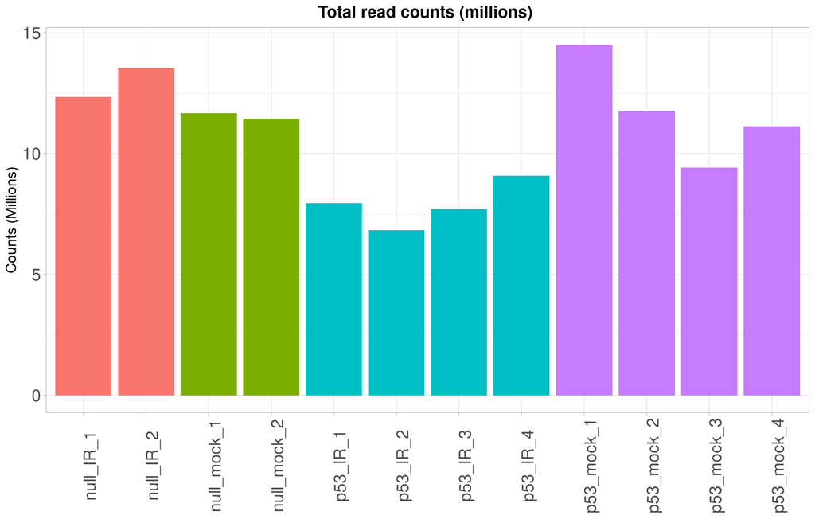

```r
total_counts_ggplot(
  counts_data = processed_data$raw_counts,
  sample_info = loaded_data$sample_info
)
```

#### **`eda_scatter`** Function

Another useful plot is a scatter plot of the transformed expression for two samples in the data. `eda_scatter` provides a scatter plot of two specified sample (columns) of the processed data. `plot_xaxis` and `plot_yaxis` are string names of the columns to be plotted. The options for these inputs can be seen using `colnames(processed_data$data)`. `processed_data` is the returned data from the `pre_process` function.

```r
colnames(processed_data$data)
```

```
##  [1] "p53_mock_1"  "p53_mock_2"  "p53_mock_3"  "p53_mock_4"  "p53_IR_1"
##  [6] "p53_IR_2"    "p53_IR_3"    "p53_IR_4"    "null_mock_1" "null_mock_2"
## [11] "null_IR_1"   "null_IR_2"
```

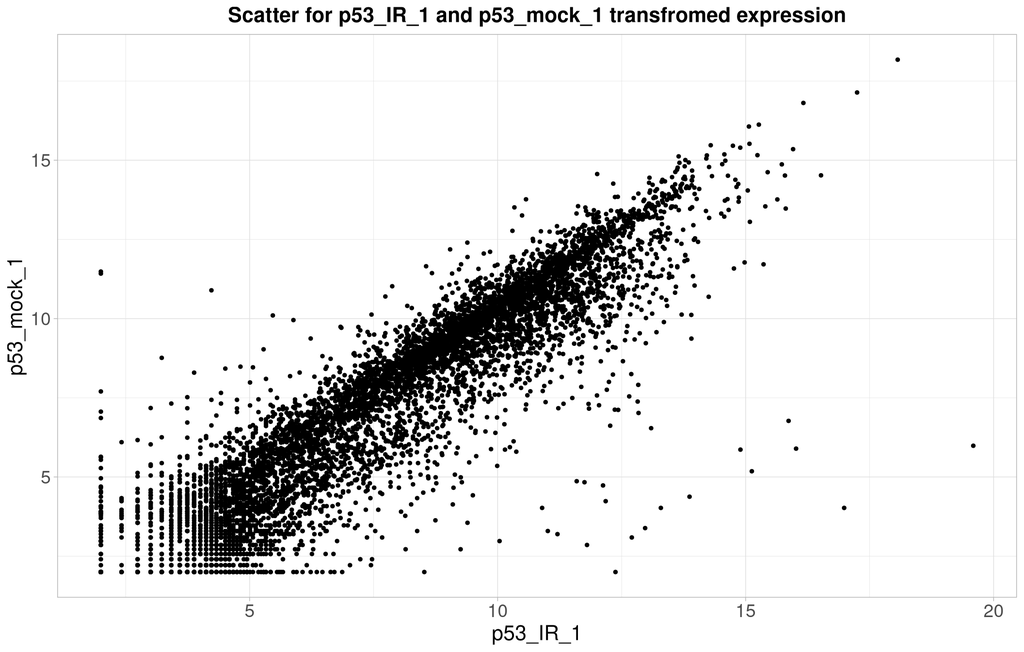

```r
eda_scatter(
  processed_data = processed_data$data,
  plot_xaxis = "p53_IR_1",
  plot_yaxis = "p53_mock_1"
)
```

#### **`eda_boxplot`** Function

`eda_boxplot` will show the distribution of the counts data after the pre-processing transformation. This function returns a ggplot boxplot of each column in the data. `processed_data` is the transformed counts and `sample_info` is the experiment design information from the `input_data` function.

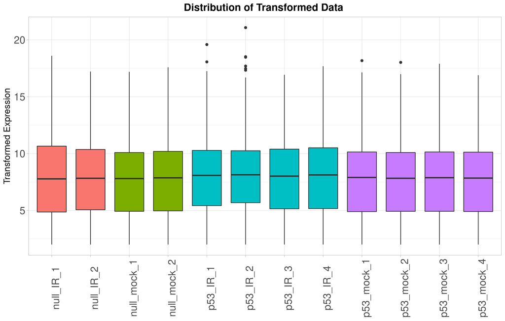

```r
eda_boxplot(
  processed_data = processed_data$data,
  sample_info = loaded_data$sample_info
)
```

#### **`eda_density`** Function

```r
eda_density(
  processed_data = processed_data$data,
  sample_info = loaded_data$sample_info
)
```

[figure not shown]

#### `merge_data` Function

The current data is using the converted ensembl IDs as rownames in a large data matrix, but the following function will create a data frame containing the gene names from the `get_all_gene_names` function. `merge_data` takes the `gene_names` data frame and a data matrix with ID rownames and creates a data frame with columns for each ID that idep has matched from the original IDs. This is useful to view different IDs for the same gene. It also enables writing CSV files that can be saved and be used to reproduce results from idep. The following code will merge the gene names with the raw counts data and the transformed data from `pre_process`.

```r
merged_raw_counts <- merge_data(
  all_gene_names = gene_names,
  data = processed_data$raw_counts
)

merged_data <- merge_data(
  all_gene_names = gene_names,
  data = processed_data$data
)
```

#### SEARCHING

```r
# Species search for input data
idep_data$species_choice[grep("Human", names(idep_data$species_choice))]
```

```
## $Human
## [1] "80"
```

```r
# Gene search for individual plotting
merged_data[grep("H4c1", merged_data$symbol),]
```

```
##                 User_ID         ensembl_ID                  symbol p53_mock_1
## 5258 ENSMUSG00000069306 ENSMUSG00000069306 H4c1 ENSMUSG00000069306       3.70
## 5174 ENSMUSG00000067455 ENSMUSG00000067455                   H4c11       9.36
## 4933 ENSMUSG00000060678 ENSMUSG00000060678 H4c1 ENSMUSG00000060678      11.50
##      p53_mock_2 p53_mock_3 p53_mock_4 p53_IR_1 p53_IR_2 p53_IR_3 p53_IR_4
## 5258       3.24       3.44       2.00     3.00     4.11     2.00     3.18
## 5174       8.77       9.26       8.52     8.30     7.75     8.42     8.50
## 4933      11.01      11.58      11.20    11.15    11.30    11.59    11.46
##      null_mock_1 null_mock_2 null_IR_1 null_IR_2
## 5258       11.47       11.23     11.56     10.52
## 5174        9.30        9.12      8.91      8.46
## 4933       12.08       12.00     11.78     11.11
```